# Análisis de expresión diferencial y visualización de resultados con Bioconductor

Octubre 26, 2016

## Paquetes opcionales

- EnsDb.Hsapiens.v75 son como 50 mb

```r
source("https://bioconductor.org/biocLite.R")
biocLite(c("vsn", "EnsDb.Hsapiens.v75"))
```

## Análisis de expresión diferencial con *DESeq2*

- **El objeto *DESeqDataSet***.
- Normalización de datos (parámetro \(s_j\)).
- Estimación de las dispersiones (parámetro \(\alpha_i\)).
- Comparaciones sencillas (tratamiento vs control).
- Comparaciones con factores de bloqueo.
- Comparaciones con interacciones.
- Transformaciones a los datos de conteo.

## Creación de un objeto *DESeqDataSet* I

Primero, vamos a especificar el directorio en el que se encuentran los archivos de conteo

```r
path <- "."

countMatrixFile <-
  file.path( path, "genomeeting_counts.tsv" )

countMatrixFile
```

```
## [1] "./genomeeting_counts.tsv"
```

```r
sampleAnnotationFile <-
  file.path( path, "genomeeting_sample_summary.tsv" )

sampleAnnotationFile
```

```
## [1] "./genomeeting_sample_summary.tsv"
```

## Creación de un objeto *DESeqDataSet* II

Una vez especificados la dirección a los archivos, importamos los datos dentro de *R*. Comenzamos leyendo la matrix de cuentas por cada muestra.

```r
countMatrix <- read.delim( countMatrixFile, row.names=1 )
head( countMatrix )
```

```
##                 SRR1039508 SRR1039509 SRR1039512
## ENSG00000000003        679        448        873
## ENSG00000000005          0          0          0
## ENSG00000000419        467        515        621
## ENSG00000000457        260        211        263
## ENSG00000000460         60         55         40
## ENSG00000000938          0          0          2
##                 SRR1039513 SRR1039516 SRR1039517
## ENSG00000000003        408       1138       1047
## ENSG00000000005          0          0          0
## ENSG00000000419        365        587        799
## ENSG00000000457        164        245        331
## ENSG00000000460         35         78         63
## ENSG00000000938          0          1          0
##                 SRR1039520 SRR1039521
## ENSG00000000003        770        572
## ENSG00000000005          0          0
## ENSG00000000419        417        508
## ENSG00000000457        233        229
## ENSG00000000460         76         60
## ENSG00000000938          0          0
```

## Creación de un objeto *DESeqDataSet* III

Después importamos el archivo con la anotación de las muestras:

```r
annotation <- read.delim( sampleAnnotationFile )
head( annotation )
```

```
##          Run SampleName    cell   dex albut
## 1 SRR1039508 GSM1275862  N61311 untrt untrt
## 2 SRR1039509 GSM1275863  N61311   trt untrt
## 3 SRR1039512 GSM1275866 N052611 untrt untrt
## 4 SRR1039513 GSM1275867 N052611   trt untrt
## 5 SRR1039516 GSM1275870 N080611 untrt untrt
## 6 SRR1039517 GSM1275871 N080611   trt untrt
##   avgLength Experiment    Sample    BioSample
## 1       126  SRX384345 SRS508568 SAMN02422669
## 2       126  SRX384346 SRS508567 SAMN02422675
## 3       126  SRX384349 SRS508571 SAMN02422678
## 4        87  SRX384350 SRS508572 SAMN02422670
## 5       120  SRX384353 SRS508575 SAMN02422682
## 6       126  SRX384354 SRS508576 SAMN02422673
```

## Creación de un objeto *DESeqDataSet* IV

Es importante verificar que el orden de las columnas de la matriz de cuentas esté en el mismo orden que las filas el *data.frame* de anotación:

```r
all( colnames( countMatrix ) == annotation$Run )
```

```
## [1] TRUE
```

## Creación de un objeto *DESeqDataSet* V

Ya preparados nuestros datos, llamamos a la función que genera el *DESeqDataSet* a partir de nuestra matriz de cuentas y el *data.frame* con la anotación de cada muestra.

```r
suppressMessages( library('DESeq2') )
dsd <- DESeqDataSetFromMatrix(
  countData = countMatrix, colData = annotation,
  design = ~ dex,
  )
dsd
```

```
## class: DESeqDataSet
## dim: 64102 8
## metadata(1): version
## assays(1): counts
## rownames(64102): ENSG00000000003
##   ENSG00000000005 ... LRG_98 LRG_99
## rowData names(0):
## colnames(8): SRR1039508 SRR1039509 ...
##   SRR1039520 SRR1039521
## colData names(9): Run SampleName ... Sample
##   BioSample
```

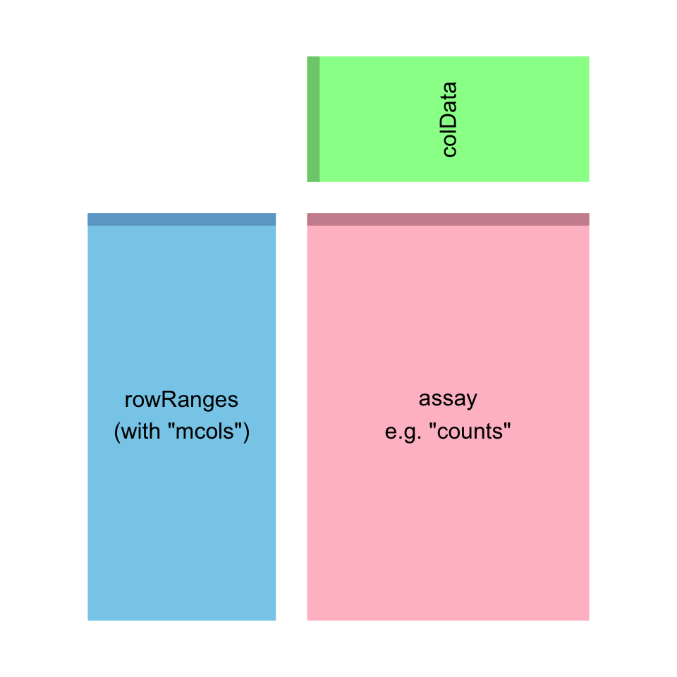

## Exploración del *DESeqDataSet* I

```r
head( counts( dsd ) )
```

```
##                 SRR1039508 SRR1039509 SRR1039512
## ENSG00000000003        679        448        873
## ENSG00000000005          0          0          0
## ENSG00000000419        467        515        621
## ENSG00000000457        260        211        263
## ENSG00000000460         60         55         40
## ENSG00000000938          0          0          2
##                 SRR1039513 SRR1039516 SRR1039517
## ENSG00000000003        408       1138       1047
## ENSG00000000005          0          0          0
## ENSG00000000419        365        587        799
## ENSG00000000457        164        245        331
## ENSG00000000460         35         78         63
## ENSG00000000938          0          1          0
##                 SRR1039520 SRR1039521
## ENSG00000000003        770        572
## ENSG00000000005          0          0
## ENSG00000000419        417        508
## ENSG00000000457        233        229
## ENSG00000000460         76         60
## ENSG00000000938          0          0
```

## Exploración del *DESeqDataSet* II

```r
colData( dsd )[,c("Run", "Sample", "dex")]
```

```
## DataFrame with 8 rows and 3 columns
##                   Run    Sample      dex
##              <factor>  <factor> <factor>
## SRR1039508 SRR1039508 SRS508568    untrt
## SRR1039509 SRR1039509 SRS508567      trt
## SRR1039512 SRR1039512 SRS508571    untrt
## SRR1039513 SRR1039513 SRS508572      trt
## SRR1039516 SRR1039516 SRS508575    untrt
## SRR1039517 SRR1039517 SRS508576      trt
## SRR1039520 SRR1039520 SRS508579    untrt
## SRR1039521 SRR1039521 SRS508580      trt
```

## Exploración del *DESeqDataSet* III

```r
rowRanges( dsd )
```

```
## GRangesList object of length 64102:
## $ENSG00000000003
## GRanges object with 0 ranges and 0 metadata columns:
##    seqnames    ranges strand
##       <Rle> <IRanges>  <Rle>
##
## $ENSG00000000005
## GRanges object with 0 ranges and 0 metadata columns:
##      seqnames ranges strand
##
## $ENSG00000000419
## GRanges object with 0 ranges and 0 metadata columns:
##      seqnames ranges strand
##
## ...
## <64099 more elements>
## -------
## seqinfo: no sequences
```

## Exploración del *DESeqDataSet* IV

```r
mcols( dsd )
```

```
## DataFrame with 64102 rows and 0 columns
```

## Generando sub sets del *DESeqDataSet*

```r
dsdSubset <- dsd[,1:4]
dim( counts( dsdSubset ) )
```

```
## [1] 64102     4
```

```r
dim( colData( dsdSubset ) )
```

```
## [1] 4 9
```

## Ejercicio 1

- ¿Cuántos fragmentos fueron secuenciados del gen ENSG00000003137 en la muestra SRR1039521?
- ¿Cual es el identificador del experimento de la muestra SRR1039512?

## Solución 1

```r
counts(dsd)['ENSG00000003137', 'SRR1039521']
```

```
## [1] 68
```

```r
colData(dsd)$Experiment[colData(dsd)$Run == 'SRR1039512']
```

```
## [1] SRX384349
## 8 Levels: SRX384345 SRX384346 ... SRX384358
```

## Análisis de expresión diferencial con *DESeq2*

- El objeto *DESeqDataSet*.
- **Normalización de datos (parámetro \(s_j\))**.
- Estimación de las dispersiones (parámetro \(\alpha_i\)).
- Comparaciones sencillas (tratamiento vs control).
- Comparaciones con factores de bloqueo.
- Comparaciones con interacciones.
- Transformaciones a los datos de conteo.

## Normalización de datos I

¿Porqué debemos normalizar los datos?

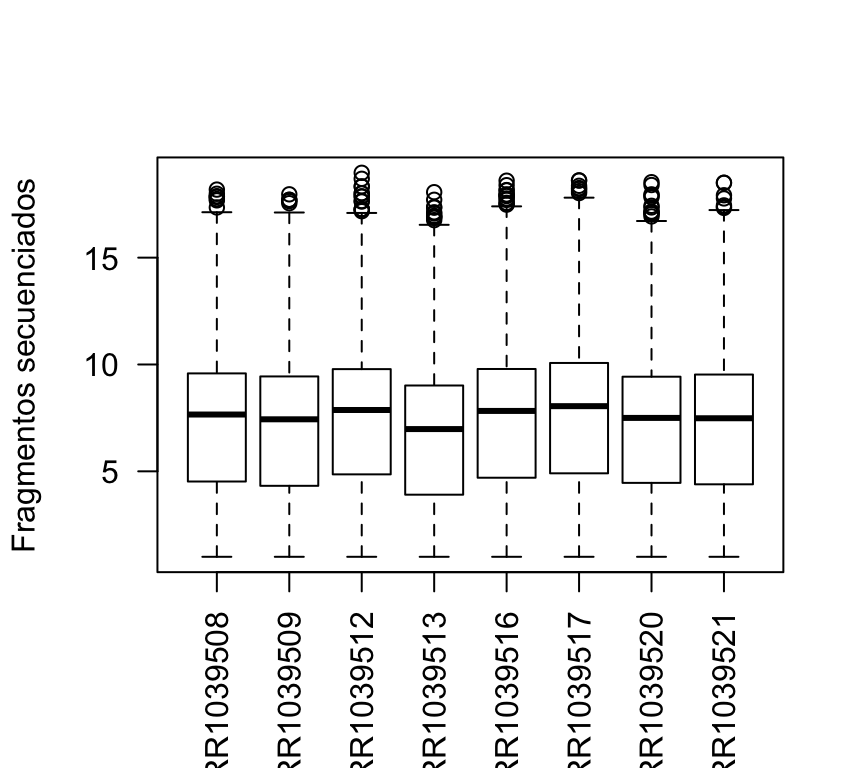

```r
hasCounts <- rowSums( counts(dsd) > 0 ) == ncol(dsd)
boxplot( log2( counts( dsd )[hasCounts,] + 1 ) , las=2,
  ylab="Fragmentos secuenciados", srt = 45)
```

## Normalización de datos II

\(\hat{s}_{j} = median_{i} \frac{k_{ij}}{( \prod_{v=1}^{m}k_{iv} )^{\frac{1}{m}}}\)

## Normalización de datos III

Llamamos a la función *estimateSizeFactors*:

```r
dsd <- estimateSizeFactors( dsd )

sizeFactors( dsd )
```

```
## SRR1039508 SRR1039509 SRR1039512 SRR1039513
##  1.0236476  0.8961667  1.1794861  0.6700538
## SRR1039516 SRR1039517 SRR1039520 SRR1039521
##  1.1776714  1.3990365  0.9207787  0.9445141
```

```r
colData( dsd )[, "sizeFactor"]
```

```
## SRR1039508 SRR1039509 SRR1039512 SRR1039513
##  1.0236476  0.8961667  1.1794861  0.6700538
## SRR1039516 SRR1039517 SRR1039520 SRR1039521
##  1.1776714  1.3990365  0.9207787  0.9445141
```

## Ejercicio II

Repetir el boxplot anterior, pero ahora con los cuentas normalizadas. Pista: el código es casi idéntico, cambia sólo un parametro de la function *counts*.

## Solución II

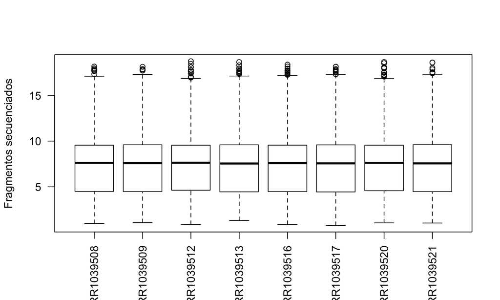

```r
boxplot( log2(
    counts( dsd, normalized = TRUE )[hasCounts,] + 1 ) , las=2,
    ylab="Fragmentos secuenciados", srt = 45)
```

## Análisis de expresión diferencial con *DESeq2*

- El objeto *DESeqDataSet*
- Normalización de datos (parámetro \(s_j\)).
- **Estimación de las dispersiones (parámetro \(\alpha_i\))**.
- Comparaciones sencillas (tratamiento vs control).
- Comparaciones con factores de bloqueo.
- Comparaciones con interacciones.
- Transformaciones a los datos de conteo.

## Estimación de las dispersiones I

¿Porqué no podemos estimar la varianza con métodos comunes de máxima verosimilitud?

## Estimación de las dispersiones II

Tres pasos importantes:

1. Estimar la dispersión por cada gen.
2. Modelar la relación entre media y varianza.
   - Asumiendo que: genes con medias similares tendrán varianzas similares.
   - Compartiendo información entre genes.
3. Calcular un compromiso entre dispersiones individuales y la dispersión compartida.

## Estimación de las dispersiones III

```r
dsd <- estimateDispersions( dsd )
```

## Estimación de las dispersiones IV

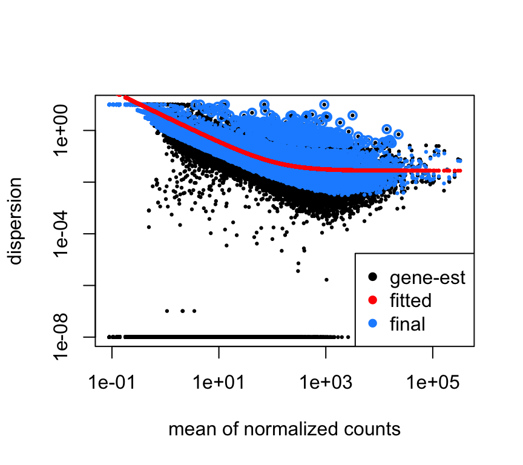

```r
plotDispEsts( dsd )
```

## Ejercicio III

¿En qué campo del *DESeqDataSet* se guarda la información de las dispersiones?

## Solución III

```r
rowData(dsd)[,
    grepl('disp', colnames(rowData(dsd)))
]
```

```
## DataFrame with 64102 rows and 6 columns
##       dispGeneEst    dispFit  dispersion
##         <numeric>  <numeric>   <numeric>
## 1     0.025075298 0.03251273 0.027334343
## 2              NA         NA          NA
## 3     0.001329435 0.03423796 0.007780134
## 4     0.000000010 0.04198854 0.011068811
## 5     0.061685923 0.08605230 0.069624032
## ...           ...        ...         ...
## 64098          NA         NA          NA
## 64099          NA         NA          NA
## 64100          NA         NA          NA
## 64101          NA         NA          NA
## 64102          NA         NA          NA
##        dispIter dispOutlier     dispMAP
##       <numeric>   <logical>   <numeric>
## 1             9       FALSE 0.027334343
## 2            NA          NA          NA
## 3             7       FALSE 0.007780134
## 4             8       FALSE 0.011068811
## 5            10       FALSE 0.069624032
## ...         ...         ...         ...
## 64098        NA          NA          NA
## 64099        NA          NA          NA
## 64100        NA          NA          NA
## 64101        NA          NA          NA
## 64102        NA          NA          NA
```

## Análisis de expresión diferencial con *DESeq2*

- El objeto *DESeqDataSet*
- Normalización de datos (parámetro \(s_j\)).
- Estimación de las dispersiones (parámetro \(\alpha_i\)).
- **Comparaciones sencillas (tratamiento vs control)**
- Comparaciones con factores de bloqueo.
- Comparaciones con interacciones.
- Transformaciones a los datos de conteo.

## Comparaciones sencillas (tratamiento vs control) I

```r
dsd <- nbinomWaldTest( dsd )
res1 <- results( dsd )
```

## Comparaciones sencillas (tratamiento vs control) II

```r
summary( res1 )
```

```
##
## out of 33469 with nonzero total read count
## adjusted p-value < 0.1
## LFC > 0 (up)     : 1505, 4.5%
## LFC < 0 (down)   : 1877, 5.6%
## outliers [1]     : 98, 0.29%
## low counts [2]   : 14805, 44%
## (mean count < 4)
## [1] see 'cooksCutoff' argument of ?results
## [2] see 'independentFiltering' argument of ?results
```

## Comparaciones sencillas (tratamiento vs control) III

```r
plotCounts(dsd,
           gene=rownames(res1)[which.min(res1$padj)],
           intgroup="dex")
```

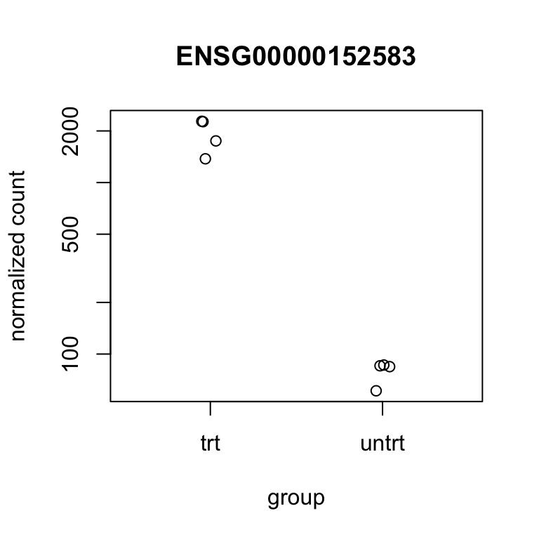

[figure not shown]

## Comparaciones sencillas (tratamiento vs control) IV

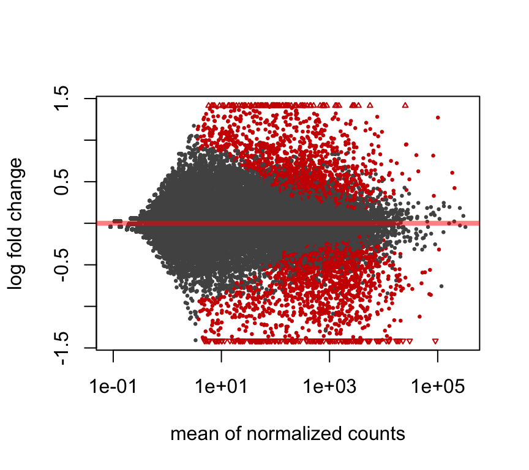

```r
plotMA( res1 )
```

## Análisis de expresión diferencial con *DESeq2*

- El objeto *DESeqDataSet*
- Normalización de datos (parámetro \(s_j\)).
- Estimación de las dispersiones (parámetro \(\alpha_i\)).
- Comparaciones sencillas (tratamiento vs control).
- **Comparaciones con factores de bloqueo.**
- Comparaciones con interacciones.
- Transformaciones a los datos de conteo.

## Comparaciones con factores de bloqueo I

¿Cuándo se usa un factor de bloqueo? Ejemplos: muestras pareadas, variables técnicas o biológicas adicionales.

```r
colData( dsd )[, c( "cell", "dex" ) ]
```

```
## DataFrame with 8 rows and 2 columns
##                cell      dex
##            <factor> <factor>
## SRR1039508   N61311    untrt
## SRR1039509   N61311      trt
## SRR1039512  N052611    untrt
## SRR1039513  N052611      trt
## SRR1039516  N080611    untrt
## SRR1039517  N080611      trt
## SRR1039520  N061011    untrt
## SRR1039521  N061011      trt
```

## Comparaciones con factores de bloqueo II

```r
dsdSimple <- dsd
design( dsd ) <-  ~ cell + dex
dsd <- estimateDispersions( dsd )
```

```
## found already estimated dispersions, replacing these
```

```r
dsd <- nbinomWaldTest( dsd )
```

## Comparaciones con factores de bloqueo III

¿Hace alguna diferencia introducir la línea celular al modelo?

```r
res2 <- results( dsd,
                 contrast=c( "dex", "trt", "untrt" ) )
table( 'complex'=res2$padj < 0.1, 'simple'=res1$padj < 0.1 )
```

```
##        simple
## complex FALSE  TRUE
##   FALSE 13058   100
##   TRUE   1529  3265
```

## Ejercicio IV

¿Cuántos genes están diferencialmente expresados entre las líneas celulares N061011 y N080611?

## Análisis de expresión diferencial con *DESeq2*

- El objeto *DESeqDataSet*
- Normalización de datos (parámetro \(s_j\)).
- Estimación de las dispersiones (parámetro \(\alpha_i\)).
- Comparaciones sencillas (tratamiento vs control).
- Comparaciones con factores de bloqueo.
- **Comparaciones con interacciones.**
- Transformaciones a los datos de conteo.

## Comparaciones con interacciones I

¿Qué genes responden al tratamiento de manera diferente entre las líneas celulares N61311 y N080611?

```r
design( dsd ) <-  ~ cell * dex
dsd <- estimateDispersions( dsd )
```

```
## found already estimated dispersions, replacing these
```

```r
dsd <- nbinomWaldTest( dsd )
```

## Comparaciones con interacciones II

```r
colData( dsd )[,c( "cell", "dex" )]
```

```
## DataFrame with 8 rows and 2 columns
##                cell      dex
##            <factor> <factor>
## SRR1039508   N61311    untrt
## SRR1039509   N61311      trt
## SRR1039512  N052611    untrt
## SRR1039513  N052611      trt
## SRR1039516  N080611    untrt
## SRR1039517  N080611      trt
## SRR1039520  N061011    untrt
## SRR1039521  N061011      trt
```

## Comparaciones con interacciones III

```r
resultsNames( dsd )
```

```
## [1] "Intercept"
## [2] "cell_N061011_vs_N052611"
## [3] "cell_N080611_vs_N052611"
## [4] "cell_N61311_vs_N052611"
## [5] "dex_untrt_vs_trt"
## [6] "cellN061011.dexuntrt"
## [7] "cellN080611.dexuntrt"
## [8] "cellN61311.dexuntrt"
```

```r
res4 <- results( dsd, list(
    "cellN61311.dexuntrt",
    "cellN080611.dexuntrt") )
```

## Comparaciones con interacciones III

```r
summary( res4 )
```

```
##
## out of 33469 with nonzero total read count
## adjusted p-value < 0.1
## LFC > 0 (up)     : 0, 0%
## LFC < 0 (down)   : 0, 0%
## outliers [1]     : 0, 0%
## low counts [2]   : 0, 0%
## (mean count < 0)
## [1] see 'cooksCutoff' argument of ?results
## [2] see 'independentFiltering' argument of ?results
```

## Expresión diferencial en una sola línea de código

```r
design(dsd) <- ~ cell + dex
dsd <- DESeq(dsd)
```

```
## found already estimated dispersions, replacing these
```

## Análisis de expresión diferencial con *DESeq2*

- El objeto *DESeqDataSet*
- Normalización de datos (parámetro \(s_j\)).
- Estimación de las dispersiones (parámetro \(\alpha_i\)).
- Comparaciones sencillas (tratamiento vs control).
- Comparaciones con factores de bloqueo.
- Comparaciones con interacciones.
- **Transformaciones a los datos de conteo.**

## Transformaciones a los datos de conteo I

Problema: dependencia de la varianza en la media ocasiona ruido

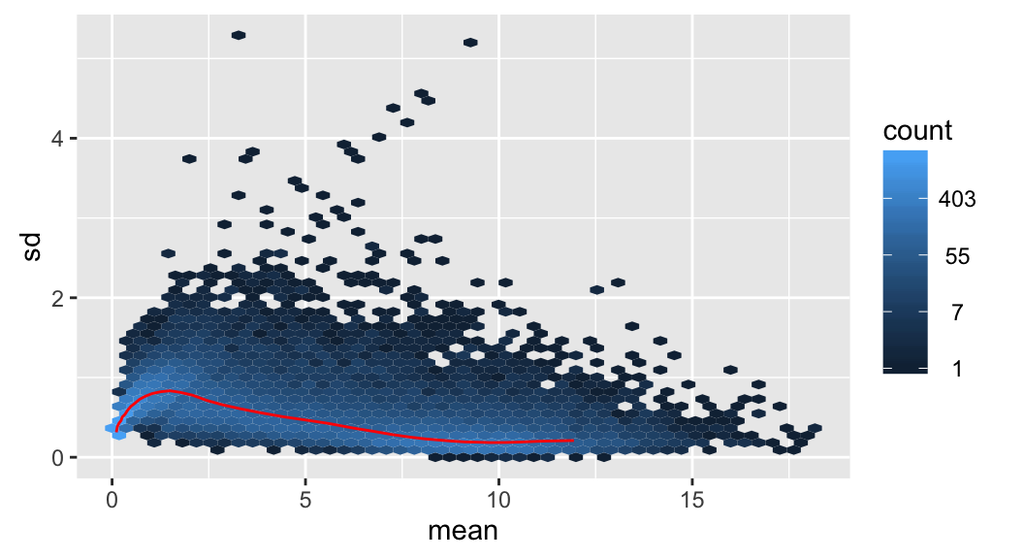

```r
suppressMessages(library('vsn'))
notAllZero <- (rowSums(counts(dsd))>0)
meanSdPlot(
  log2( counts( dsd, normalized=TRUE )[notAllZero,] + 1),
  ranks=FALSE)
```

## Transformaciones a los datos de conteo II

```r
rld <- rlog( dsd )
vsd <- varianceStabilizingTransformation(dsd)
```

## Ejercicio V

Repetir gráfico de la media y varianza, ahora con los datos transformados.

## Solución V

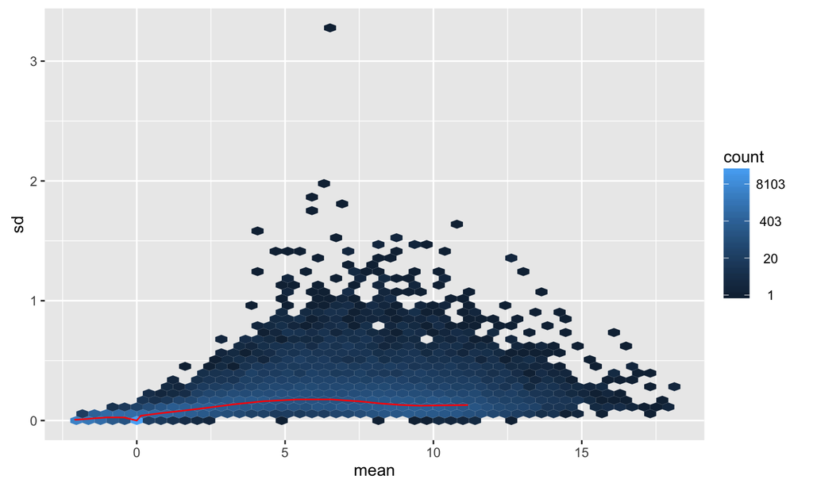

```r
meanSdPlot(assays(rld)[[1]], ranks = FALSE)
```

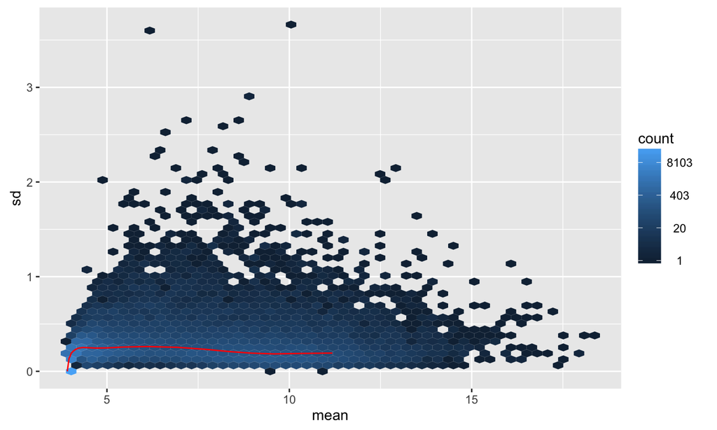

```r
meanSdPlot(assays(vsd)[[1]], ranks = FALSE)
```

## Visualizando resultados

## Mean-Average

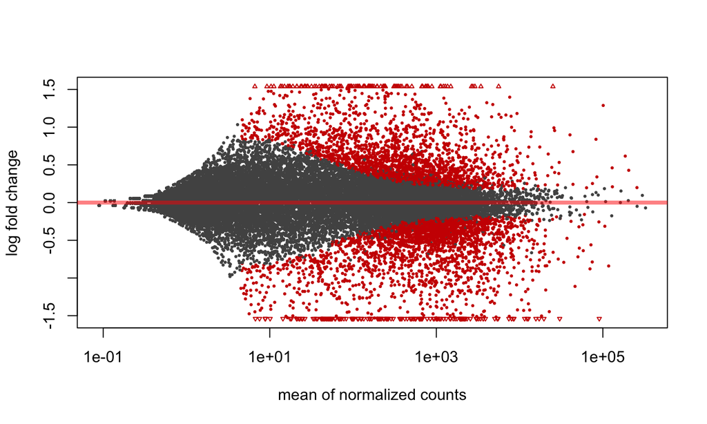

```r
plotMA(dsd)
```

```r
?plotMA
```

```
## S4 method for signature 'DESeqDataSet'
plotMA(object, alpha = 0.1, main = "",
  xlab = "mean of normalized counts", ylim, MLE = FALSE, ...)
```

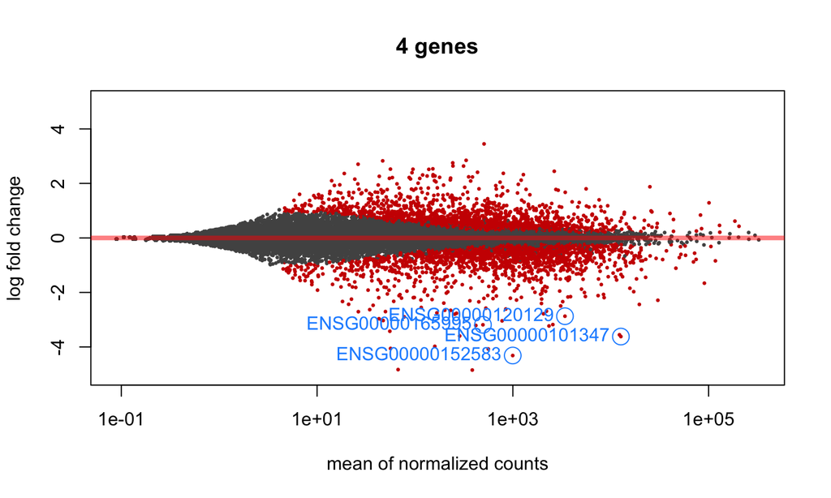

```r
res <- results(dsd, alpha = 0.05)
top <- head(order(res$padj), n = 4)
plotMA(dsd, alpha=0.05, main='4 genes', ylim = c(-5, 5))
with(res[top, ], {
  points(baseMean, log2FoldChange, col="dodgerblue", cex=2)
  text(baseMean, log2FoldChange, rownames(res)[top], pos=2,
      col="dodgerblue")
})
```

## Grupos de muestras

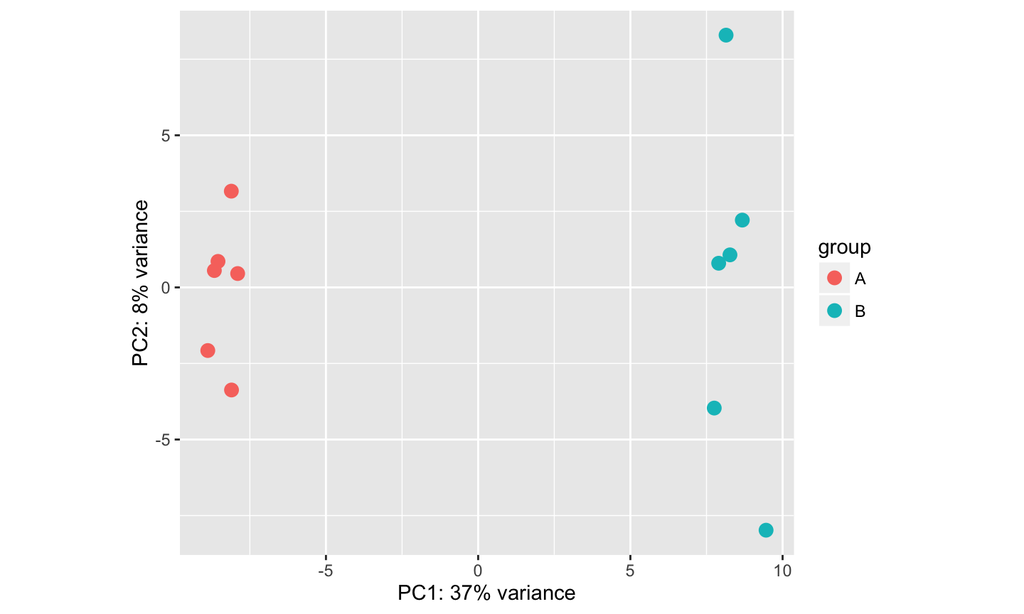

```r
prueba <- rlog(makeExampleDESeqDataSet(betaSD=1))
plotPCA(prueba)
```

## Con nuestras muestras

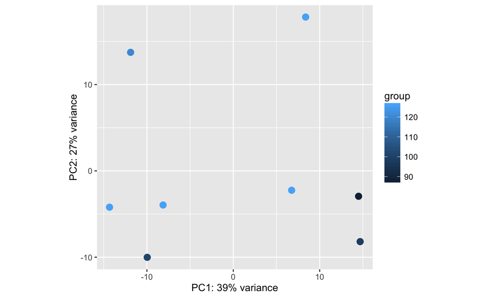

```r
plotPCA(rld, intgroup = 'avgLength')
```

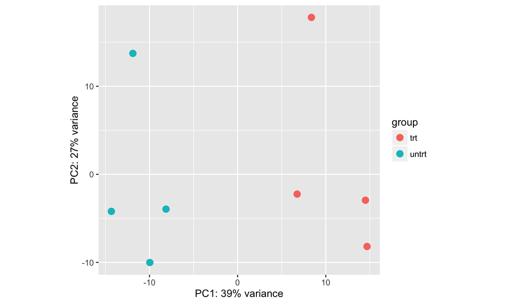

```r
plotPCA(rld, intgroup = 'dex')
```

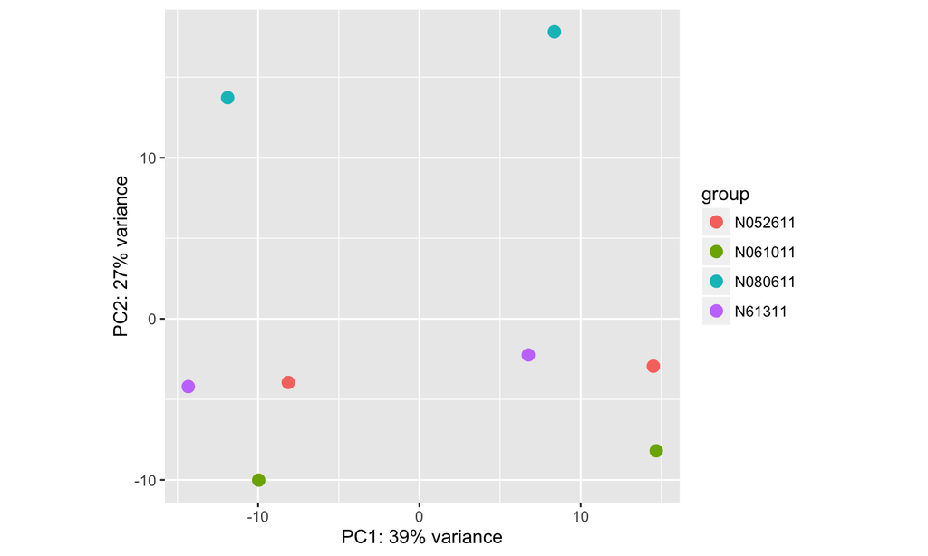

```r
plotPCA(rld, intgroup = 'cell')
```

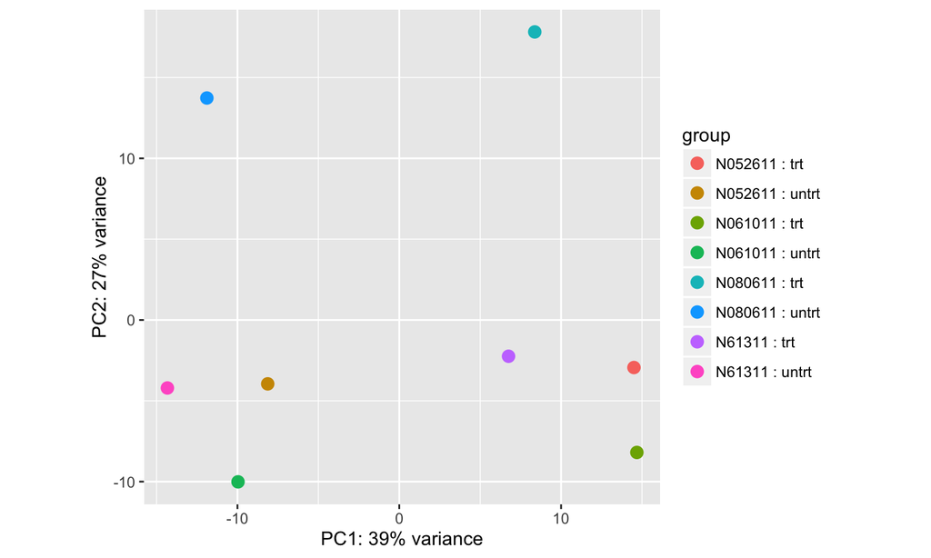

```r
plotPCA(rld, intgroup = c('cell', 'dex'))
```

## Varianza explicada

- https://github.com/Bioconductor-mirror/DESeq2/blob/master/R/plots.R

```r
rv <- matrixStats::rowVars(assay(rld))
select <- order(rv, decreasing=TRUE)[seq_len(500)]
pca <- prcomp(t(assay(rld)[select, ]))
percentVar <- pca$sdev^2 / sum( pca$sdev^2 ) * 100
names(percentVar) <- paste0('PC', seq_len(length(percentVar)))
```

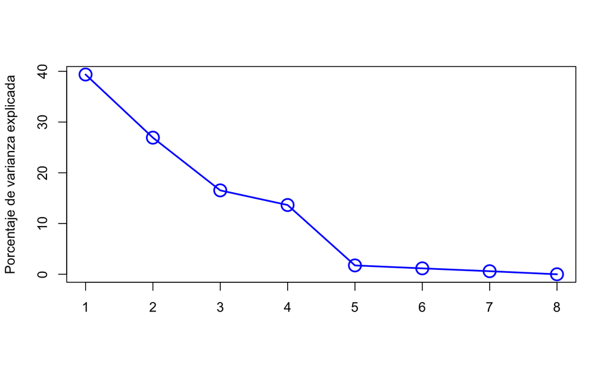

```r
plot(percentVar, type = 'o', pch = 21, cex = 2,
    xlab = '', ylab = 'Porcentaje de varianza explicada',
    col = 'blue', lwd = 2)
```

## Manhattan-plot

- Necesitamos las coordenadas de los genes

```r
library('EnsDb.Hsapiens.v75')
genes <- genes(EnsDb.Hsapiens.v75)
```

```r
genes
```

```
## GRanges object with 64102 ranges and 6 metadata columns:
##                   seqnames               ranges
##                      <Rle>            <IRanges>
##   ENSG00000223972        1       [11869, 14412]
##   ENSG00000227232        1       [14363, 29806]
##   ENSG00000243485        1       [29554, 31109]
##   ENSG00000237613        1       [34554, 36081]
##   ENSG00000268020        1       [52473, 54936]
##               ...      ...                  ...
##   ENSG00000224240        Y [28695572, 28695890]
##   ENSG00000227629        Y [28732789, 28737748]
##   ENSG00000237917        Y [28740998, 28780799]
##   ENSG00000231514        Y [28772667, 28773306]
##   ENSG00000235857        Y [59001391, 59001635]
##                   strand |         gene_id
##                    <Rle> |     <character>
##   ENSG00000223972      + | ENSG00000223972
##   ENSG00000227232      - | ENSG00000227232
##   ENSG00000243485      + | ENSG00000243485
##   ENSG00000237613      - | ENSG00000237613
##   ENSG00000268020      + | ENSG00000268020
##               ...    ... .             ...
##   ENSG00000224240      + | ENSG00000224240
##   ENSG00000227629      - | ENSG00000227629
##   ENSG00000237917      - | ENSG00000237917
##   ENSG00000231514      - | ENSG00000231514
##   ENSG00000235857      + | ENSG00000235857
##                     gene_name
##                   <character>
##   ENSG00000223972     DDX11L1
##   ENSG00000227232      WASH7P
##   ENSG00000243485  MIR1302-10
##   ENSG00000237613     FAM138A
##   ENSG00000268020      OR4G4P
##               ...         ...
##   ENSG00000224240     CYCSP49
##   ENSG00000227629  SLC25A15P1
##   ENSG00000237917     PARP4P1
##   ENSG00000231514     FAM58CP
##   ENSG00000235857     CTBP2P1
```

[output cut: 26 more lines]

```
##                        symbol
##                   <character>
##   ENSG00000223972     DDX11L1
##   ENSG00000227232      WASH7P
##   ENSG00000243485  MIR1302-10
##   ENSG00000237613     FAM138A
##   ENSG00000268020      OR4G4P
##               ...         ...
##   ENSG00000224240     CYCSP49
##   ENSG00000227629  SLC25A15P1
##   ENSG00000237917     PARP4P1
##   ENSG00000231514     FAM58CP
##   ENSG00000235857     CTBP2P1
##   -------
##   seqinfo: 273 sequences from GRCh37 genome
```

## Añadimos los qvalues

```r
## Re-ordenar
genes <- genes[match(rownames(dsd), names(genes))]
genes$pvalue <- -log10(res$padj)
length(genes)
```

```
## [1] 64102
```

```r
genes <- keepSeqlevels(genes, c(1:22, 'X', 'Y'))
length(genes)
```

```
## [1] 58153
```

```r
library('ggbio')
```

[output not shown]

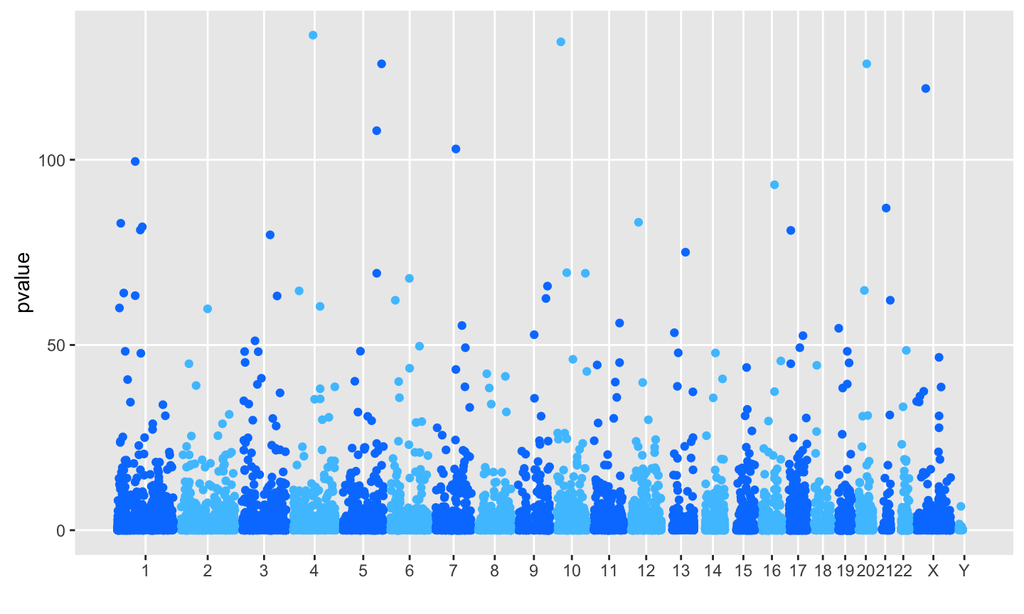

```r
plotGrandLinear(genes, aes(y = pvalue))
```

## Un gen a la vez

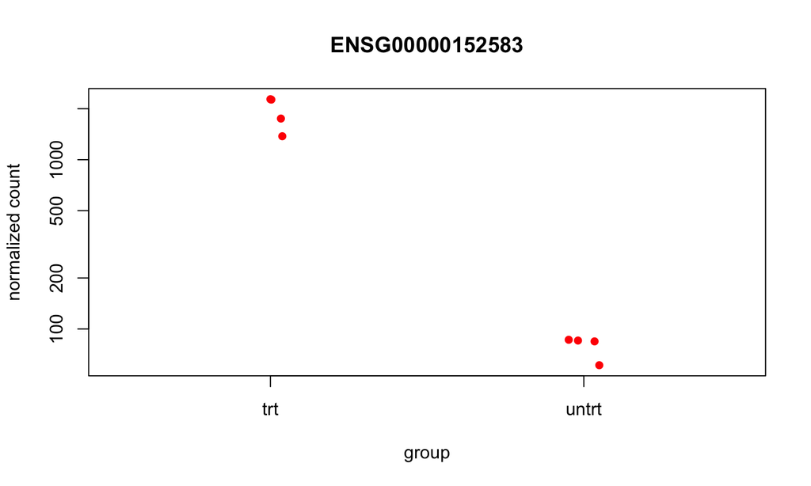

```r
plotCounts(dsd, gene = top[1], intgroup = 'dex',
    col = 'red', pch = 16)
```

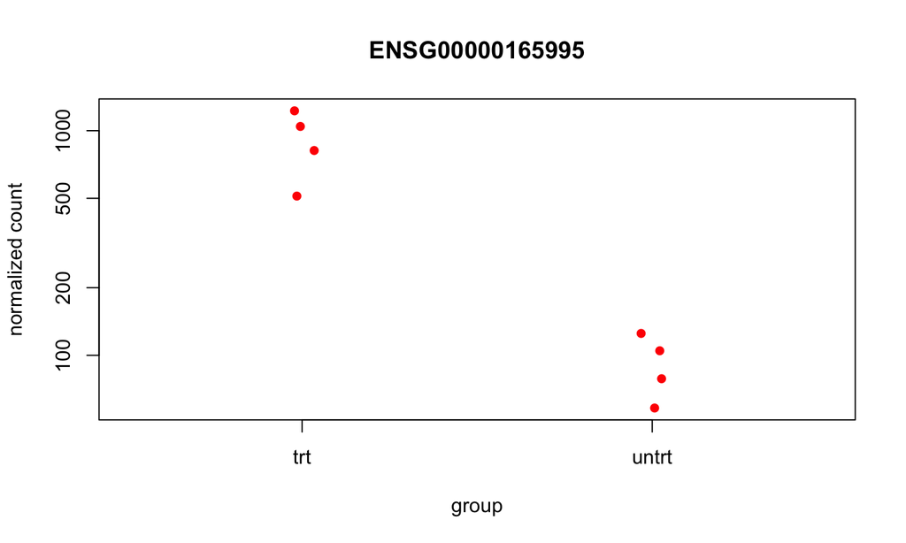

```r
plotCounts(dsd, gene = top[2], intgroup = 'dex',
    col = 'red', pch = 16)
```

## Varios genes a la vez

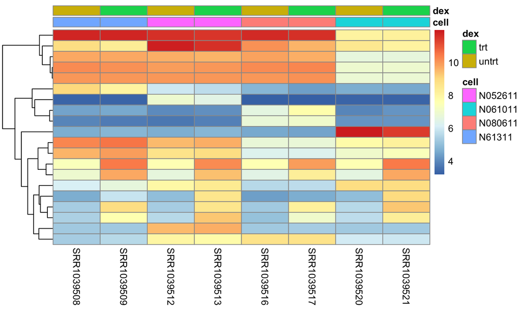

```r
library('pheatmap')
df <- as.data.frame(colData(dsd)[, c('cell', 'dex')])
pheatmap(assay(rld)[select[1:20],], cluster_rows=TRUE,
    show_rownames=FALSE, cluster_cols=FALSE, annotation_col=df)
```

## Los más expresados

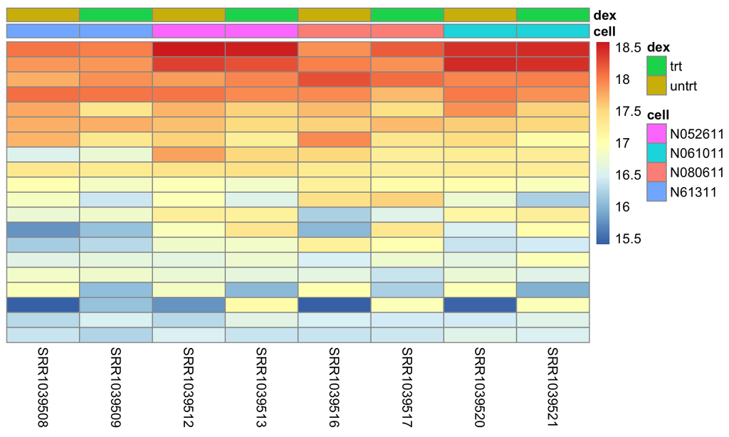

```r
select <- order(rowMeans(counts(dsd, normalized=TRUE)), decreasing=TRUE)
pheatmap(assay(rld)[select[1:20],], cluster_rows=FALSE,
    show_rownames=FALSE, cluster_cols=FALSE, annotation_col=df)
```

## Los más diferentes

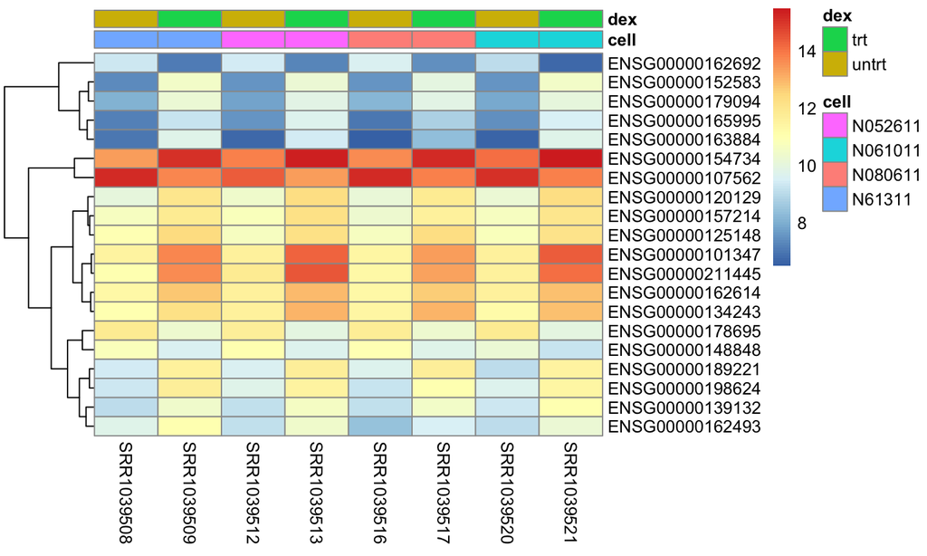

```r
select <- order(res$padj, decreasing = FALSE)
diferentes <- assay(rld)[select[1:20], ]
pheatmap(diferentes, cluster_rows=TRUE,
    show_rownames=TRUE, cluster_cols=FALSE, annotation_col=df)
```

## Con símbolos

```r
library('org.Hs.eg.db')
```

```r
coll <- function(x) { paste(x, collapse = '-')}
simbolos <- mapIds(org.Hs.eg.db,
    keys = rownames(diferentes), column = 'SYMBOL',
    keytype = 'ENSEMBL', multiVals = coll)
```

```
## keys and columns
```

```r
simbolos[1:2]
```

```
## ENSG00000152583 ENSG00000165995
##       "SPARCL1"        "CACNB2"
```

```r
## Cambiamos los nombres de los genes
rownames(diferentes) <- simbolos
```

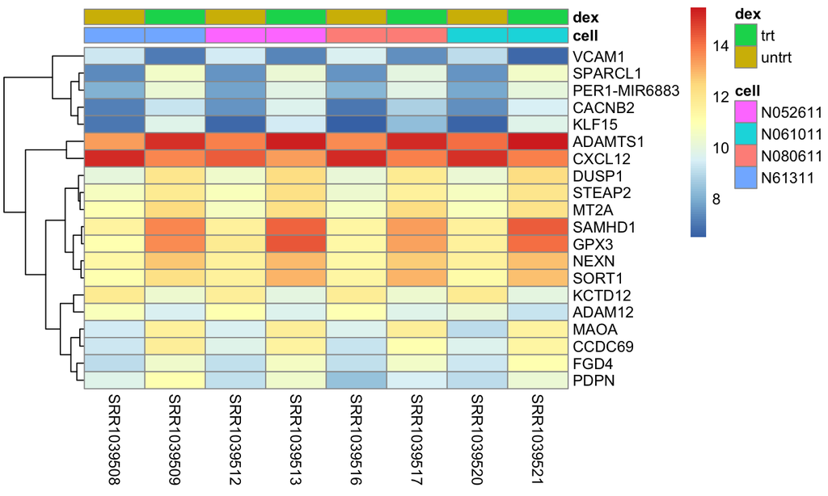

```r
pheatmap(diferentes, cluster_rows=TRUE,
    show_rownames=TRUE, cluster_cols=FALSE, annotation_col=df)
```

## Hagamos un reporte

En un archivo de texto, *conclusiones.md* copien y peguen:

````
# Nuestro heatmap

```{r 'mi_heatmap'}
library('pheatmap')
ann_df <- as.data.frame(colData(dds)[, c('cell', 'dex')])
select <- order(res$padj, decreasing = FALSE)
diferentes <- assay(rld)[select[1:20], ]
pheatmap(diferentes, cluster_rows=TRUE,
    show_rownames=TRUE, cluster_cols=FALSE,
    annotation_col=ann_df)
```

En la imagen anterior vemos...

# Conclusiones

Lo que gusten
````

```r
library('regionReport')
DESeq2Report(dds = dsd, intgroup = c('cell', 'dex'),
    nBest = 20, nBestFeatures = 2,
    customCode = file.path(getwd(), 'conclusiones.md'))
```

El reporte resultante es DESeq2Exploration

## Ejercicio final

- En el reporte muestren los símbolos de los genes en vez de los identificadores de *ENSEMBL*.
- Agreguen sus conclusiones.
- Suban su archivo html a un gist https://gist.github.com/ público
- Copien la liga
- Peguen la liga en http://rawgit.com/
- Compartan la liga a sus jefes y/o amigos =)
- Ejemplo final: [liga pública](https://rawgit.com/lcolladotor/de90dad0d82588b642964a2fa71f0204/raw/d4ebdbd864328f1bf23b44f28517c0a404957c87/DESeq2Exploration.html)

## Más información

- http://bioconductor.org/
- http://biorxiv.org/
- http://biorxiv.org/content/early/2016/08/30/021592

## Información técnica

```
##  setting  value
##  version  R version 3.3.1 (2016-06-21)
##  system   x86_64, darwin13.4.0
##  ui       X11
##  language (EN)
##  collate  en_US.UTF-8
##  tz       America/New_York
##  date     2016-10-18
```

```
##  package       * version date       source
##  acepack         1.3-3.3 2014-11-24 CRAN (R 3.3.0)
##  affy            1.51.1  2016-09-01 Bioconductor
##  affyio          1.43.0  2016-05-27 Bioconductor
##  annotate        1.51.1  2016-09-18 Bioconductor
##  AnnotationDbi * 1.35.5  2016-10-15 Bioconductor
##  AnnotationHub   2.5.14  2016-10-15 Bioconductor
##  assertthat      0.1     2013-12-06 CRAN (R 3.3.0)
##  backports       1.0.3   2016-06-28 CRAN (R 3.3.0)
##  bibtex          0.4.0   2014-12-31 CRAN (R 3.3.0)
##  Biobase       * 2.33.4  2016-10-15 Bioconductor
##  BiocGenerics  * 0.19.2  2016-07-08 Bioconductor
##  BiocInstaller   1.23.9  2016-09-04 Bioconductor
##  BiocParallel    1.7.9   2016-10-15 Bioconductor
##  biomaRt         2.29.3  2016-10-17 Bioconductor
##  Biostrings      2.41.4  2016-06-17 Bioconductor
##  biovizBase      1.21.0  2016-05-20 Bioconductor
##  bitops          1.0-6   2013-08-17 CRAN (R 3.3.0)
##  BSgenome        1.41.2  2016-06-17 Bioconductor
##  bumphunter      1.13.1  2016-07-11 Bioconductor
##  checkmate       1.8.1   2016-06-28 CRAN (R 3.3.0)
##  chron           2.3-47  2015-06-24 CRAN (R 3.3.0)
##  cluster         2.0.5   2016-10-08 CRAN (R 3.3.0)
##  codetools       0.2-15  2016-10-05 CRAN (R 3.3.1)
##  colorout      * 1.1-2   2016-05-05 Github (jalvesaq/colorout@6538970)
##  colorspace      1.2-7   2016-10-11 CRAN (R 3.3.0)
##  data.table      1.9.6   2015-09-19 CRAN (R 3.3.0)
##  DBI             0.5-1   2016-09-10 CRAN (R 3.3.0)
##  DEFormats       1.1.2   2016-05-27 Bioconductor
```

```
##  package        * version  date       source
##  knitrBootstrap   1.0.0    2016-05-05 Github (jimhester/knitrBootstrap@cdaa4a9)
##  labeling         0.3      2014-08-23 CRAN (R 3.3.0)
##  lattice          0.20-34  2016-09-06 CRAN (R 3.3.0)
##  latticeExtra     0.6-28   2016-02-09 CRAN (R 3.3.0)
##  limma            3.29.24  2016-10-17 Bioconductor
##  locfit           1.5-9.1  2013-04-20 CRAN (R 3.3.0)
##  lubridate        1.6.0    2016-09-13 CRAN (R 3.3.0)
##  magrittr         1.5      2014-11-22 CRAN (R 3.3.0)
##  markdown         0.7.7    2015-04-22 CRAN (R 3.3.0)
##  Matrix           1.2-7.1  2016-09-01 CRAN (R 3.3.0)
##  matrixStats      0.51.0   2016-10-09 CRAN (R 3.3.0)
##  memoise          1.0.0    2016-01-29 CRAN (R 3.3.0)
##  mime             0.5      2016-07-07 CRAN (R 3.3.0)
##  munsell          0.4.3    2016-02-13 CRAN (R 3.3.0)
##  nnet             7.3-12   2016-02-02 CRAN (R 3.3.1)
##  org.Hs.eg.db   * 3.4.0    2016-10-06 Bioconductor
##  OrganismDbi      1.15.2   2016-10-15 Bioconductor
##  pheatmap       * 1.0.8    2015-12-11 CRAN (R 3.3.0)
##  pkgmaker         0.22     2014-05-14 CRAN (R 3.3.0)
##  plyr             1.8.4    2016-06-08 CRAN (R 3.3.0)
##  preprocessCore   1.35.0   2016-05-27 Bioconductor
##  qvalue           2.5.2    2016-05-27 Bioconductor
##  R6               2.2.0    2016-10-05 CRAN (R 3.3.1)
##  RBGL             1.49.3   2016-08-14 Bioconductor
##  RColorBrewer     1.1-2    2014-12-07 CRAN (R 3.3.0)
##  Rcpp             0.12.7   2016-09-05 CRAN (R 3.3.0)
##  RCurl            1.95-4.8 2016-03-01 CRAN (R 3.3.0)
##  RefManageR       0.11.0   2016-09-11 CRAN (R 3.3.1)
```

```
##  package                * version date       source
##  evaluate                 0.10    2016-10-11 CRAN (R 3.3.0)
##  foreach                  1.4.3   2015-10-13 CRAN (R 3.3.0)
##  foreign                  0.8-67  2016-09-13 CRAN (R 3.3.0)
##  formatR                  1.4     2016-05-09 CRAN (R 3.3.0)
##  Formula                  1.2-1   2015-04-07 CRAN (R 3.3.0)
##  genefilter               1.55.2  2016-05-27 Bioconductor
##  geneplotter              1.51.0  2016-05-05 Bioconductor
##  GenomeInfoDb           * 1.9.15  2016-10-15 Bioconductor
##  GenomicAlignments        1.9.6   2016-07-17 Bioconductor
##  GenomicFeatures        * 1.25.20 2016-10-03 Bioconductor
##  GenomicFiles             1.9.12  2016-07-31 Bioconductor
##  GenomicRanges          * 1.25.95 2016-10-17 Bioconductor
##  GGally                   1.2.0   2016-07-01 CRAN (R 3.3.0)
##  ggbio                  * 1.21.7  2016-10-15 Bioconductor
##  ggplot2                * 2.1.0   2016-03-01 CRAN (R 3.3.0)
##  graph                    1.51.0  2016-05-05 Bioconductor
##  gridExtra                2.2.1   2016-02-29 CRAN (R 3.3.0)
##  gtable                   0.2.0   2016-02-26 CRAN (R 3.3.0)
##  hexbin                 * 1.27.1  2015-08-19 CRAN (R 3.3.0)
##  Hmisc                    3.17-4  2016-05-02 CRAN (R 3.3.0)
##  htmltools                0.3.5   2016-03-21 CRAN (R 3.3.0)
##  httpuv                   1.3.3   2015-08-04 CRAN (R 3.3.0)
##  httr                     1.2.1   2016-07-03 CRAN (R 3.3.0)
##  interactiveDisplayBase   1.11.3  2016-05-20 Bioconductor
##  IRanges                * 2.7.17  2016-10-15 Bioconductor
##  iterators                1.0.8   2015-10-13 CRAN (R 3.3.0)
##  knitcitations            1.0.7   2015-10-28 CRAN (R 3.3.0)
##  knitr                  * 1.14    2016-08-13 CRAN (R 3.3.0)
```

[output not shown]

```
##  package           * version  date       source
##  survival            2.39-5   2016-06-26 CRAN (R 3.3.0)
##  tibble              1.2      2016-08-26 CRAN (R 3.3.0)
##  VariantAnnotation   1.19.13  2016-10-17 Bioconductor
##  vsn               * 3.41.8   2016-10-17 Bioconductor
##  withr               1.0.2    2016-06-20 CRAN (R 3.3.0)
##  XML                 3.98-1.4 2016-03-01 CRAN (R 3.3.0)
##  xtable              1.8-2    2016-02-05 CRAN (R 3.3.0)
##  XVector             0.13.7   2016-07-24 Bioconductor
##  yaml                2.1.13   2014-06-12 CRAN (R 3.3.0)
##  zlibbioc            1.19.0   2016-05-05 Bioconductor
```